# NBA Players Statistics Analysis

Ngoc Nguyen

12/11/2022

# 1 Introduction

For each game played in the NBA a number of statistics about the player performance are collected which provides an over viewer of player performance. This data provides us with useful information on the player’s form at a particular time in the season. These statistics are available from a number of sources providing useful information about player performance from game to game. We have collected data for a combined four seasons from https://www.nbastuffer.com.

In this analysis, we explore the possibility of predicting the player performance in the next game based on their performance statistics in the previous games. This takes a number of player statistics as predictor variables and try to predict the player’s points per game (ppg). predicting the ppg given the previous player’s statistics will enable us to have an idea of the form of the player and their likely performance in future games.

# 2 Methodology for the Analysis

# 3 Load the Data

```r
source('config/00_dependencies.R')
```

```r
load("data/nba_dataset.RData")

str(nba_dataset)
```

```
## 'data.frame':    2555 obs. of  27 variables:
##  $ team        : chr  "Okc" "Pho" "Atl" "Okc" ...
##  $ pos         : chr  "G" "F" "G" "C" ...
##  $ age         : num  25.7 28.5 22.9 25.7 21.7 ...
##  $ gp          : num  31 10 34 80 82 19 7 81 10 38 ...
##  $ mpg         : num  19 12.3 12.6 33.4 23.3 10.2 3.1 33.2 12 11 ...
##  $ min_perc    : num  39.5 25.6 26.2 69.5 48.6 21.3 6.4 69.1 25.1 22.8 ...
##  $ usg_per     : num  12.2 9.2 13.5 16.4 15.8 9.9 25.5 27 19 24.4 ...
##  $ to_perc     : num  7.9 15.2 19.7 12.8 17.1 13.7 15.5 8.8 15.3 13.9 ...
##  $ fta         : num  13 10 9 292 226 4 2 412 12 60 ...
##  $ fta_perc    : num  0.923 0.7 0.778 0.5 0.735 1 0.5 0.847 0.667 0.75 ...
##  $ two_pa      : num  30 3 36 807 471 ...
##  $ two_p_perc  : num  0.5 0.667 0.361 0.596 0.588 0.385 0.5 0.528 0.37 0.443 ...
##  $ three_pa    : num  127 15 74 2 15 23 4 42 12 99 ...
##  $ three_p_perc: num  0.323 0.133 0.338 0 0.2 0.261 0 0.238 0.25 0.323 ...
##  $ efg_perc    : num  0.487 0.278 0.459 0.595 0.579 0.389 0.3 0.522 0.372 0.466 ...
##  $ ts_perc     : num  0.507 0.379 0.474 0.591 0.623 0.424 0.322 0.576 0.418 0.516 ...
##  $ ppg         : num  5.3 1.7 3.2 13.9 8.9 1.7 1 21.3 3.7 5.6 ...
##  $ rpg         : num  1.5 2.5 1.8 9.5 7.3 1 0.6 9.2 2.6 0.6 ...
##  $ trb_perc    : num  4.2 11.3 7.5 14.7 16.6 5.4 10 15.1 11.7 3.1 ...
##  $ apg         : num  0.6 0.8 1.9 1.6 2.2 0.3 0.9 2.4 1.3 0.7 ...
##  $ ast_perc    : num  4.3 8.2 20.2 6.6 14.2 3.4 37.9 11.6 15.2 8.9 ...
##  $ spg         : num  0.55 0.1 0.38 1.49 0.88 0.05 0.29 0.54 0.1 0.13 ...
##  $ bpg         : num  0.19 0.4 0.15 0.96 0.79 0.21 0 1.32 0 0.16 ...
##  $ topg        : num  0.45 0.4 0.82 1.73 1.48 0.32 0.29 1.78 0.8 0.87 ...
##  $ vi          : num  3.5 4.9 7 7.1 9 3.1 10.5 9.4 7.7 4.8 ...
##  $ ortg        : num  103.1 87.1 99.5 119.9 120 ...
##  $ drtg        : num  103.9 98.5 108.1 102.7 97.2 ...
```

The loaded `nba_dataset` has a total of 27 variables with 2555 observations. Only two of the variables are of character type with the rest being numerical.

# 4 Exploratory Data Analysis

## 4.1 Check for Missing Values

```r
missing_total <- sum(is.na(nba_dataset))

missing <- colSums(is.na(nba_dataset))

missing_df <- data.frame(missing) %>%
  filter(missing > 0)
```

The dataset has a total of 331 missing values.

The following are the variable with the missing data:

|  | missing |
| --- | --- |
| to_perc | 22 |
| efg_perc | 25 |
| ts_perc | 23 |
| ortg | 132 |
| drtg | 129 |

## 4.2 Continous Variables

### 4.2.1 Filter Continous Variables

```r
cont_vars <- select_if(nba_dataset, is.numeric)
```

### 4.2.2 Descriptive Statistics

```r
st(cont_vars)
```

Summary Statistics

| Variable | N | Mean | Std. Dev. | Min | Pctl. 25 | Pctl. 75 | Max |
| --- | --- | --- | --- | --- | --- | --- | --- |
| age | 2555 | 26.626 | 4.152 | 19.2 | 23.355 | 29.255 | 43.55 |
| gp | 2555 | 38.189 | 24.74 | 1 | 15 | 61 | 82 |
| mpg | 2555 | 19.082 | 9.439 | 0.6 | 11.4 | 27.1 | 43.5 |
| min_perc | 2555 | 39.749 | 19.665 | 1.3 | 23.8 | 56.5 | 90.7 |
| usg_per | 2555 | 18.396 | 6.028 | 0 | 14.6 | 21.7 | 67.9 |
| to_perc | 2533 | 12.477 | 6.883 | 0 | 9.1 | 14.8 | 100 |
| fta | 2555 | 80.865 | 105.053 | 0 | 11 | 108 | 858 |
| fta_perc | 2555 | 0.688 | 0.245 | 0 | 0.64 | 0.833 | 1 |
| two_pa | 2555 | 196.843 | 224.371 | 0 | 29 | 286.5 | 1393 |
| two_p_perc | 2555 | 0.493 | 0.156 | 0 | 0.451 | 0.569 | 1 |
| three_pa | 2555 | 122.259 | 143.531 | 0 | 10 | 194 | 1028 |
| three_p_perc | 2555 | 0.289 | 0.154 | 0 | 0.24 | 0.376 | 1 |
| efg_perc | 2530 | 0.503 | 0.127 | 0 | 0.471 | 0.56 | 1.5 |
| ts_perc | 2532 | 0.534 | 0.121 | 0 | 0.5 | 0.591 | 1.5 |
| ppg | 2555 | 8.396 | 6.257 | 0 | 3.7 | 11.5 | 36.1 |
| rpg | 2555 | 3.517 | 2.445 | 0 | 1.8 | 4.7 | 15.8 |
| trb_perc | 2555 | 10.093 | 5.43 | 0 | 6.4 | 12.75 | 57.4 |
| apg | 2555 | 1.875 | 1.79 | 0 | 0.7 | 2.4 | 11.7 |
| ast_perc | 2555 | 13.054 | 9.362 | 0 | 6.9 | 17.5 | 100.3 |
| spg | 2555 | 0.605 | 0.418 | 0 | 0.3 | 0.86 | 2.5 |
| bpg | 2555 | 0.384 | 0.4 | 0 | 0.11 | 0.51 | 3.38 |
| topg | 2555 | 1.048 | 0.818 | 0 | 0.495 | 1.38 | 5 |
| vi | 2555 | 6.713 | 2.629 | 0 | 5.5 | 8.1 | 21.8 |
| ortg | 2423 | 108.459 | 16.906 | 0 | 102 | 116.9 | 300 |
| drtg | 2426 | 105.15 | 5.94 | 66.2 | 101.9 | 109.2 | 124.5 |

The total number of observations for all the variables is 2555. The range of ages for the observed players ranges from about 19 years to about 44 years. Variables that are measured in percentages ranges from 0 to a maximum of 100 whereas those measured in per unit ranges from 0 to 1. we also note variables with very wide range such as two_pa 9range from 0 to 1393), three_pa(range from 0 to 1028) and fta (with range from 0 to 858). We note that thes varying ranges in the data distribution will have to be taken care of before fitting the model. This means that we will have to standardize our predictor variables so that they fall within a similar range.

The response variable of ppg (points per game) ranges from 0 to 36.1 with a mean of 8.396 and a standard deviation of 6.257.

### 4.2.3 Continous Variables Distribution

```r
continous_long <- cont_vars %>%
  pivot_longer(colnames(cont_vars)) %>%
  as.data.frame()

head(continous_long)
```

```
##       name value
## 1      age 25.69
## 2       gp 31.00
## 3      mpg 19.00
## 4 min_perc 39.50
## 5  usg_per 12.20
## 6  to_perc  7.90
```

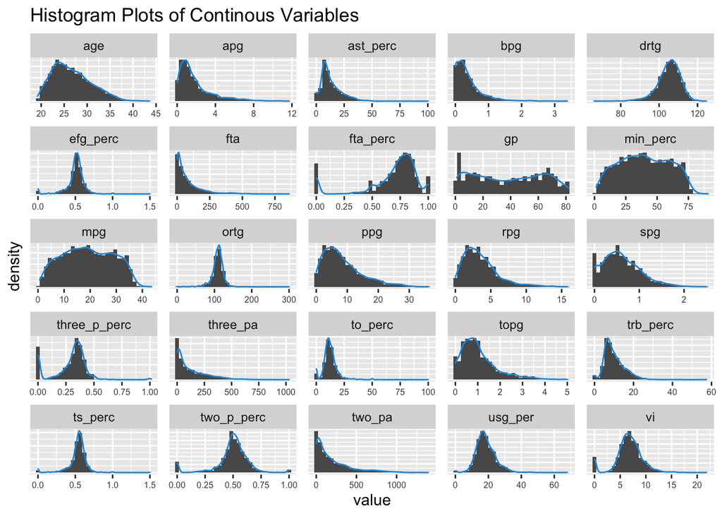

Fig 1. Histogram Plots of Continous Variables

```r
p1 <- ggplot(continous_long, aes(x = value)) +
  geom_histogram(aes(y = after_stat(density), bins=16)) +
  geom_density(col = "#1b98e0", size = 0.5) +
  facet_wrap(~ name, scales = "free", ncol=5, as.table=TRUE)

p1 + theme(axis.text = element_text(size=6),
           axis.text.y = element_blank(),
           axis.ticks.x = element_line(),
           axis.ticks.y = element_blank())+
  ggtitle("Histogram Plots of Continous Variables")
```

We note that the response variable of ppg seems to be skewed to the right which is an indication of higher oputlier points per games observed. A number of predictor variables are equally noticed to have upper outliers making their distributions skewed to the right. This right skewness can be noticed in the following variables: `age`, `apa`, `ast_perc`,`bpg`,`fta`,`rpg`, `spg`, `three_p_perc`, `three_pa`, to_perc`,`topg`, trb_perc`, `two_pa`, `usg_per` and `vi`.

the variables `min_per`, `gp`, and `mpg` seems to have distributions that are close to uniform and the following distributions have noticeable outlines on the lowers end; `grtg` and `fta_perc`.

Standardizing the variables will ensure to have all the variables with a mean of o and standard deviation of 1.

### 4.2.4 Relationship among the Continous Variables

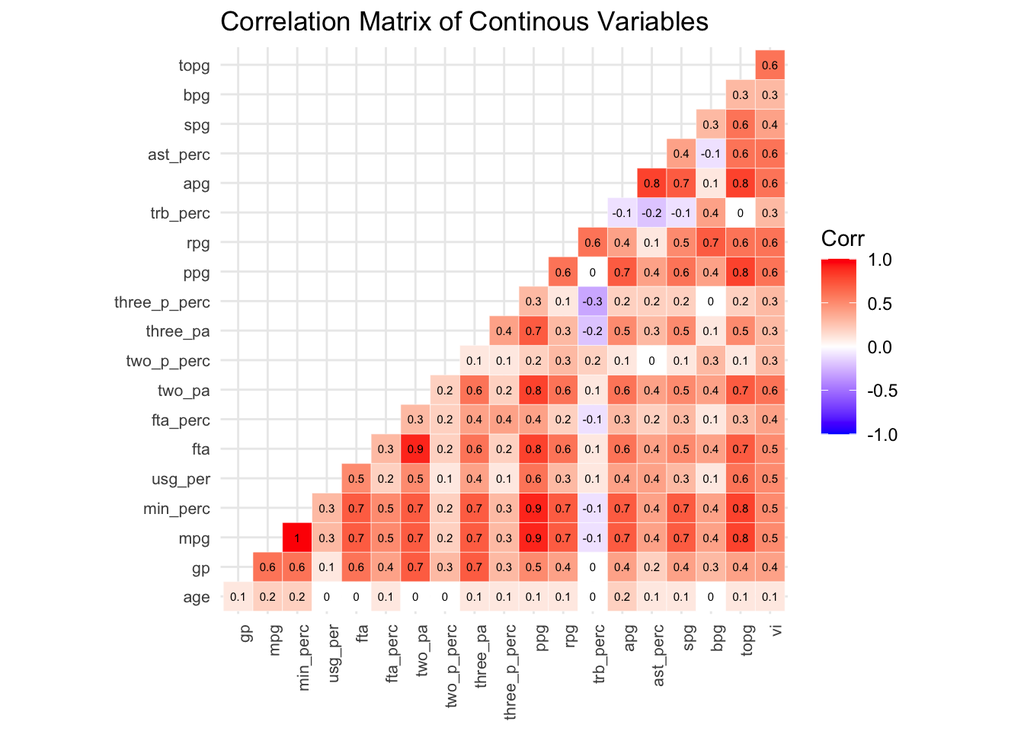

Fig 2. Correlation Matrix of Continous Variables

```r
corr <- round(cor(cont_vars), 1)

ggcorrplot(corr, type = "lower",
   outline.col = "white", lab=TRUE, lab_size=2, tl.cex=8,  tl.srt=90)+
ggtitle("Correlation Matrix of Continous Variables")
```

the variables `mpg` and `min-perc` are perfectly correlated with a correlation coefficient of 1. In order to avoid the issues of multicollinearity once we fit our model, one of the two highly correlated will have to be dropped before fitting the model. This will apply to all other highly correlated variables which might bring about multicollinearity issues in our model.

We have two categorical variables in our dataset: `team` and `pos` which are the team name where the player plays and the position they play respectively. We will explore the distribution of these categorical variables and how they relate with the response variable.

```r
cat <- select_if(nba_dataset, is.character)
head(cat)
```

```
##   team pos
## 1  Okc   G
## 2  Pho   F
## 3  Atl   G
## 4  Okc   C
## 5  Mia C-F
## 6  Cle   F
```

### 4.3.1 Frequency Distribution Tables

```r
tbl_summary(cat)
```

| **Characteristic** | **N = 2,555**<sup>1</sup> |
| --- | --- |
| team |  |
| Atl | 85 (3.3%) |
| Bos | 83 (3.2%) |
| Bro | 94 (3.7%) |
| Cha | 69 (2.7%) |
| Chi | 83 (3.2%) |
| Cle | 99 (3.9%) |
| Dal | 86 (3.4%) |
| Den | 83 (3.2%) |
| Det | 90 (3.5%) |
| Gol | 74 (2.9%) |
| Hou | 93 (3.6%) |
| Ind | 82 (3.2%) |
| Lac | 85 (3.3%) |
| Lal | 86 (3.4%) |
| Mem | 91 (3.6%) |
| Mia | 82 (3.2%) |
| Mil | 92 (3.6%) |
| Min | 79 (3.1%) |
| Nor | 80 (3.1%) |
| Nyk | 82 (3.2%) |
| Okc | 84 (3.3%) |
| Orl | 86 (3.4%) |
| Phi | 91 (3.6%) |
| Pho | 83 (3.2%) |
| Por | 81 (3.2%) |
| Sac | 93 (3.6%) |
| San | 76 (3.0%) |
| Tor | 85 (3.3%) |
| Uta | 80 (3.1%) |
| Was | 98 (3.8%) |
| pos |  |
| 0 | 1 (<0.1%) |
| C | 212 (8.3%) |
| C-F | 95 (3.7%) |
| F | 755 (30%) |
| F-C | 180 (7.0%) |
| F-G | 94 (3.7%) |
| G | 980 (38%) |
| G-F | 238 (9.3%) |

<sup>1</sup> n (%)

We note that the variable team has a total number of 30 distinct levels whereas the variable `pos` has a total of 8. We believe that the team to which one belongs will have an impact on the performance of a player and as such despite having these number of levels, we will maintain these categories. The coding of these categories will have to be handled in the reprocessing of the data before fitting the model.

The `pos` variable has a position indicated as `0` with only one observation. Since we do not have a `0` as position this is likely to be a missing value coded as zero. We will replace this value with `NA` so that we can handle it in the handling of missing values during the pre-processing of data.

```r
nba_dataset <- nba_dataset %>%
  mutate_at(vars(pos),
            function(.var){
              if_else(condition = (.var==0), # if true (i.e. the entry is 0)
                      true = as.character(NA), # replace the value with NA
                      false = .var) # otherwise leave it as it is
            })
```

### 4.3.2 Frequency Plots of Categorical Variables

```r
cat <- select_if(nba_dataset, is.character)

cat_long <- cat %>%
  pivot_longer(colnames(cat)) %>%
  as.data.frame()

head(cat_long)
```

```
##   name value
## 1 team   Okc
## 2  pos     G
## 3 team   Pho
## 4  pos     F
## 5 team   Atl
## 6  pos     G
```

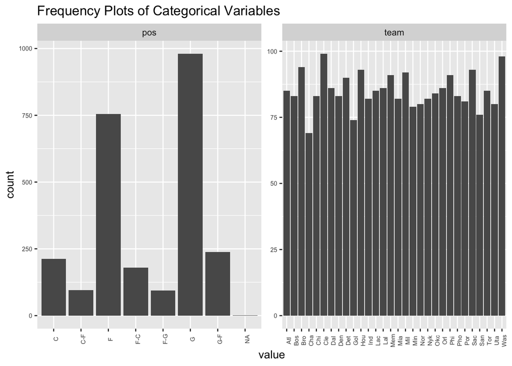

Fig 3.Frequency Plots of Categorical Variables

```r
p2 <- ggplot(cat_long, aes(x = value)) +
  geom_bar() +
  facet_wrap(~ name, scales = "free", ncol=4, as.table=TRUE)

p2 + theme(axis.text = element_text(size=6),
           axis.text.x = element_text(angle=90)) +
  ggtitle("Frequency Plots of Categorical Variables")
```

We note that majority of the players play in position ‘G’ followed by those who play in postion ‘F’. The distribution of observations across the teams is fairly close to uniform ranging between about 65 to about 100 observations per team. Next, we consider how the response variable varies accross the two categorical variables.

### 4.3.3 Response Variables Across Categorical Variables

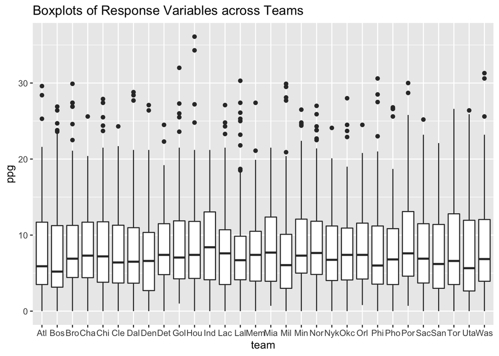

Fig 4.BoxPlots of of ppg across team

```r
ggplot(nba_dataset, aes(x=team, y=ppg)) +
    geom_boxplot() +
  ggtitle('Boxplots of Response Variables across Teams')
```

We note that the median ppg for the various teams ranges within 5 to 10 points. The distribution of the median is fairly within the same range for all of the teams with a number of upper outlines for most of the teams.

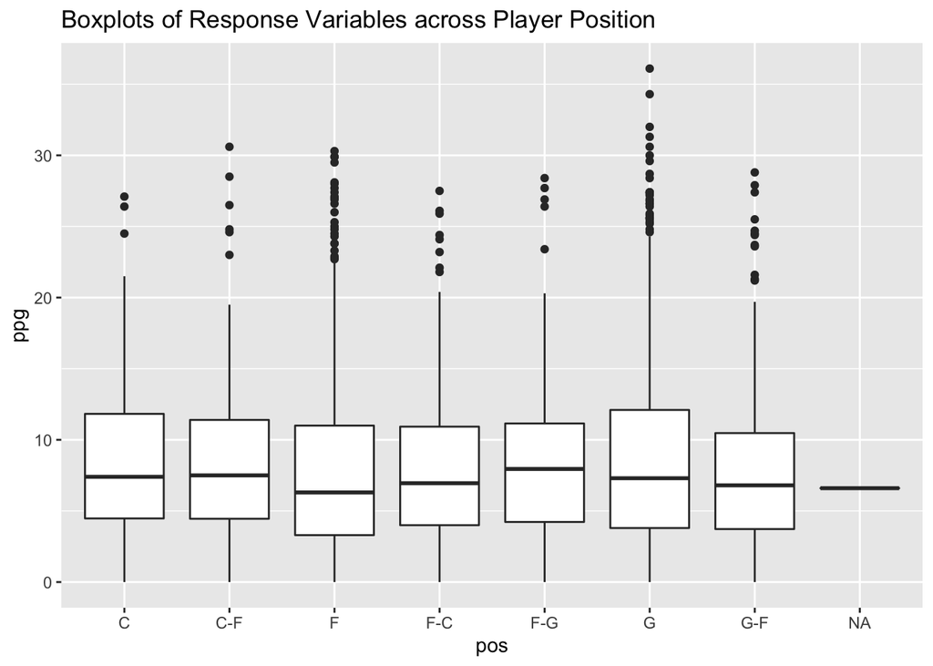

Fig 5.BoxPlots of of ppg across pos

```r
ggplot(nba_dataset, aes(x=pos, y=ppg)) +
    geom_boxplot() +
  ggtitle('Boxplots of Response Variables across Player Position')
```

There is no significant noticeable difference in the median ppg for the various positions.

# 5 Train-Test Split

we split the data into 80% of training data and 20% of test data. The training data is further partitioned into validation folds that are used to tune the fitted models inorder to optimize performance.

```r
set.seed(1234)

nba_split <- initial_split(nba_dataset,
                            pro = 4/5)

nba_split
```

```
## <Training/Testing/Total>
## <2044/511/2555>
```

next, create a cross-validation version of a training set.

```r
set.seed(1234)

nba_train <- training(nba_split)
nba_test <- testing(nba_split)

nba_cv <- vfold_cv(nba_train)
```

# 6 Feature Engineering

The following feature engineering are applied to the data for model fitting:

- definition the predictor and response variables
- The following pre-processing is applied to the data:
  - Data Standardization of all numerical variables.
  - Impute all missing values using the k-nearest neighbour method.
  - one-hot encoding of the categorical variables.
  - Omitting of highly correlated variables.
  - Omitting of variables with low variance.

```r
nba_recipe <- recipe(ppg ~., data = nba_dataset) %>%
  step_normalize(all_numeric()) %>%
  step_impute_knn(all_predictors) %>%
  step_dummy(team, pos, one_hot = TRUE) %>%
  step_corr(all_predictors(), - mpg) %>%
  step_nzv(all_predictors())

nba_recipe
```

```
## Recipe
##
## Inputs:
##
##       role #variables
##    outcome          1
##  predictor         26
##
## Operations:
##
## Centering and scaling for all_numeric()
## K-nearest neighbor imputation for all_predictors
## Dummy variables from team, pos
## Correlation filter on all_predictors(), -mpg
## Sparse, unbalanced variable filter on all_predictors()
```

# 7 Conclusion

In this analysis, we explore the prediction the player performance in the next game based on their performance statistics in the previous games. This takes a number of player statistics as predictor variables and try to predict the player’s points per game (ppg). Predicting the ppg given the previous player’s statistics will enable us to have an idea of the form of the player and their likely performance in future games. We found that the response variable of ppg (points per game) ranges from 0 to 36.1 with a mean of 8.396 and a standard deviation of 6.257. We find that there is no significant difference in the median ppg for the different positions.